# Data analysis and visualization using R (1)

Dataframe manipulations

Michiel Noback

December 2019

# Introduction

Dataframes are ubiquitous in R-based data analyses. Many R functions and packages are tailored specifically for DF manipulations - you have already seen `cbind()`, `rbind()` and `subset()`.  
In this presentation, we’ll explore a few new functions and techniques for working with DFs:

- `apply()`
- `lapply()`
- `sapply()`
- `tapply()`
- `aggregate()`
- `split()`

# `apply()` and family

# The apply family of functions

Looping with `for` may be tempting, but highly discouraged in R because its inefficient. Ususally one of these functions will do it better:

- `apply`: Apply a function over the “margins” of a dataframe - rows or columns or both
- `lapply`: Loop over a list and evaluate a function on each element; returns a list of the same length
- `sapply`: Same as lapply but try to simplify the result
- `tapply`: Apply a function over subsets of a vector (read: split with a factor)

There are more but these are the important ones.

# Basic apply usage

- Suppose you want to know the means of all columns of a dataframe.
- `apply()` needs to know
  1. what DF to apply to (`X`)
  2. over which margin(s) - columns and/or rows (`MARGIN`)
  3. what function to apply (`FUN`)

```r
apply(X = cars, MARGIN = 2, FUN = mean) # apply over columns
```

```
speed  dist
15.40 42.98
```

# Both margins

Here, a function is applied to both columns and rows

```r
df <- data.frame(x = 1:5, y = 6:10)
minus_one_squared <- function(x) (x-1)^2
apply(X = df, MARGIN = c(1,2), FUN = minus_one_squared)
```

```
      x  y
[1,]  0 25
[2,]  1 36
[3,]  4 49
[4,]  9 64
[5,] 16 81
```

(That was a bit lame: `minus_one_squared(df)` does the same)

# `apply()` example: BMI

- BMI is calculated as $(weight / height ^ 2) * 703$ where weight is in pounds and height in inches.

```r
head(women, n=3)
```

```
  height weight
1     58    115
2     59    117
3     60    120
```

```r
women$bmi <- apply(X = women,
                   MARGIN = 1,
                   FUN = function(x) (x[2] / x[1]^2) * 703)
head(women, n=4)
```

```
  height weight   bmi
1     58    115 24.03
2     59    117 23.63
3     60    120 23.43
4     61    123 23.24
```

# Pass arguments to the applied function

- Sometimes the applied function needs to have other arguments passed besides the row or column.
- The `...` argument to apply makes this possible (type ?apply to see more info)

```r
# function sums and powers up
spwr <- function(x, p = 2) {sum(x)^p}
# a simple dataframe
df <- data.frame(a = 1:5, b = 6:10)
df
```

```
  a  b
1 1  6
2 2  7
3 3  8
4 4  9
5 5 10
```

```r
df
```

```
  a  b
1 1  6
2 2  7
3 3  8
4 4  9
5 5 10
```

```r
# spwr will use the default value for p (p = 2)
apply(X = df, MARGIN = 1, FUN = spwr)
```

```
[1]  49  81 121 169 225
```

```r
# pass power p = 3 to function spwr (argument names omitted)
apply(df, 1, spwr, p = 3)
```

```
[1]  343  729 1331 2197 3375
```

Note: The `...` argument works for all `apply` functions.

# `lapply()`: apply to a list

- `lapply()` applies a function to all elements of a list and returns a list with the same length, each element the result of applying the function

```r
myNumbers = list(
    one = c(1, 3, 4),
    two = c(3, 2, 6, 1),
    three = c(5, 7, 6, 8, 9))
lapply(X = myNumbers, FUN = mean)
```

```
$one
[1] 2.667

$two
[1] 3

$three
[1] 7
```

- Same, but with `sqrt()` applied
- Note how the nature of the applied function influences the result

```r
lapply(X = myNumbers, FUN = sqrt)
```

```
$one
[1] 1.000 1.732 2.000

$two
[1] 1.732 1.414 2.449 1.000

$three
[1] 2.236 2.646 2.449 2.828 3.000
```

# `sapply()`: apply to a list and try to simplify

- When using the same example as above, but with `sapply`, you get a vector returned
- Note that the resulting vector is a named vector

```r
myNumbers = list(
    one = c(1, 3, 4),
    two = c(3, 2, 6, 1),
    three = c(5, 7, 6, 8, 9))
sapply(X = myNumbers, FUN = mean)
```

```
  one   two three
2.667 3.000 7.000
```

# wasn’t a dataframe also a list?

Yes! It is also list(ish). Both `lapply()` and `sapply()` work just fine on dataframes:

```r
lapply(X = cars, FUN = mean)
```

```
$speed
[1] 15.4

$dist
[1] 42.98
```

```r
sapply(X = cars, FUN = mean)
```

```
speed  dist
15.40 42.98
```

By the way, sapply and lapply also work with vectors.

# `tapply()`: split and apply

- `tapply()`: Apply a function over subsets of a vector
- -> Split a vector into groups according to the levels in a second vector and apply the given function to each group

```r
tapply(X = chickwts$weight, INDEX = chickwts$feed, FUN = sd)
```

```
   casein horsebean   linseed  meatmeal   soybean sunflower
    64.43     38.63     52.24     64.90     54.13     48.84
```

# `split()`: split into groups

- Use `split()` when a dataframe needs to be divided depending on the value of some grouping variable. The result is a list, with a member for each grouping value
- Here we have the response of Treated (T) and Untreated (UT) subjects

```r
myData <- data.frame(
    response = c(5, 8, 4, 5, 9, 3, 6, 7, 3, 6, 5, 2),
    treatment = factor(
        c("UT", "T", "UT", "UT", "T", "UT", "T", "T", "UT", "T", "T", "UT")))
splData <- split(x = myData, f = myData$treatment)
str(splData)
```

```
List of 2
 $ T :'data.frame': 6 obs. of  2 variables:
  ..$ response : num [1:6] 8 9 6 7 6 5
  ..$ treatment: Factor w/ 2 levels "T","UT": 1 1 1 1 1 1
 $ UT:'data.frame': 6 obs. of  2 variables:
  ..$ response : num [1:6] 5 4 5 3 3 2
  ..$ treatment: Factor w/ 2 levels "T","UT": 2 2 2 2 2 2
```

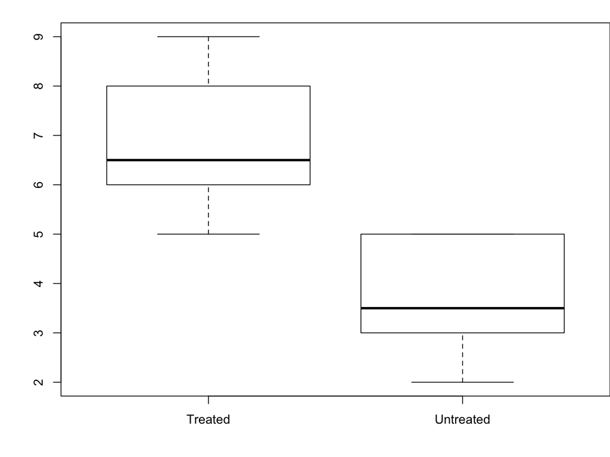

```r
## this trivial example could also have been done with
## boxplot(myData$response ~ myData$treatment)
boxplot(splData$T$response, splData$UT$response,
        names = c("Treated", "Untreated"))
```

Note: split also works with vectors

```r
split(x = rnorm(10), f = rep(c("sick", "healthy"), each=5))
```

```
$healthy
[1]  3.68758  0.94272 -0.94735 -0.08422  0.46945

$sick
[1] -1.7102 -0.1007  0.5781 -0.5542  1.1436
```

# `aggregate()`: Compute summary statistics of subsets

Splits the data into subsets, computes summary statistics for each, and returns the result in a convenient form.

```r
aggregate(formula = Temp ~ Month, data = airquality, FUN = mean)
```

```
  Month  Temp
1     5 65.55
2     6 79.10
3     7 83.90
4     8 83.97
5     9 76.90
```

# Two usages of `aggregate()`

Aggregate has two usages:

- formula:  
  **`aggregate(formula, data, FUN, ...)`**
- by:  
  **`aggregate(x, by, FUN, ...)`**

I really like `aggregate()`, especially the first form.

Both will be demonstrated

# Aggregate with formula

The left part of the formula accepts one, several or all columns as dependent variables.

```r
##two dependents
aggregate(cbind(Temp, Ozone) ~ Month, data = airquality, FUN = mean)
```

```
  Month  Temp Ozone
1     5 66.73 23.62
2     6 78.22 29.44
3     7 83.88 59.12
4     8 83.96 59.96
5     9 76.90 31.45
```

```r
##all
aggregate(. ~ Month, data = airquality, FUN = mean)
```

```
  Month Ozone Solar.R   Wind  Temp   Day
1     5 24.12   182.0 11.504 66.46 16.08
2     6 29.44   184.2 12.178 78.22 14.33
3     7 59.12   216.4  8.523 83.88 16.23
4     8 60.00   173.1  8.861 83.70 17.17
5     9 31.45   168.2 10.076 76.90 15.10
```

The right part can also accept multiple independent variables

```r
airquality$Temp_factor <- cut(airquality$Temp, breaks = 2, labels = c("low", "high"))
aggregate(Ozone ~ Month + Temp_factor, data = airquality, FUN = mean)
```

```
   Month Temp_factor Ozone
1      5         low 18.92
2      6         low 20.50
3      7         low 13.00
4      8         low 16.00
5      9         low 17.62
6      5        high 80.00
7      6        high 36.60
8      7        high 62.96
9      8        high 63.62
10     9        high 48.46
```

# The `by = list(...)` form

This is the other form of aggregate. It is more elaborate in my opinion because you need te spell out all vectors you want to work on.

```r
aggregate(x = chickwts$weight, by = list(feed = chickwts$feed), FUN = mean)
```

```
       feed     x
1    casein 323.6
2 horsebean 160.2
3   linseed 218.8
4  meatmeal 276.9
5   soybean 246.4
6 sunflower 328.9
```

another example

```r
aggregate(x = airquality$Wind,
          by = list(month = airquality$Month, temperature = airquality$Temp_factor),
          FUN = mean)
```

```
   month temperature      x
1      5         low 11.714
2      6         low  9.855
3      7         low 10.600
4      8         low 11.433
5      9         low 11.394
6      5        high 10.300
7      6        high 10.505
8      7        high  8.828
9      8        high  8.511
10     9        high  8.793
```

better to wrap it in `with()`:

```r
with(airquality, aggregate(x = Wind,
                           by = list(month = Month, temperature = Temp_factor),
                           FUN = mean))
```

# Many roads lead to Rome

The statements on the next slides are all essentially the same. The message is: there is more than one way to do it!

```r
aggregate(weight ~ feed, data = chickwts, FUN = mean)
```

```
       feed weight
1    casein  323.6
2 horsebean  160.2
3   linseed  218.8
4  meatmeal  276.9
5   soybean  246.4
6 sunflower  328.9
```

same as

```r
head(aggregate(x = chickwts$weight, by = list(feed = chickwts$feed), FUN = mean), n=3)
```

```
       feed     x
1    casein 323.6
2 horsebean 160.2
3   linseed 218.8
```

```r
tapply(chickwts$weight, chickwts$feed, mean)
```

```
   casein horsebean   linseed  meatmeal   soybean sunflower
    323.6     160.2     218.8     276.9     246.4     328.9
```

```r
with(chickwts, tapply(weight, feed, mean))
```

```
   casein horsebean   linseed  meatmeal   soybean sunflower
    323.6     160.2     218.8     276.9     246.4     328.9
```

```r
sapply(split(chickwts, chickwts$feed), function(x){mean(x$weight)})
```

```
   casein horsebean   linseed  meatmeal   soybean sunflower
    323.6     160.2     218.8     276.9     246.4     328.9
```

And this is the topic of the next course:

```r
library(dplyr)
group_by(chickwts, feed) %>% summarise(mean_weigth = mean(weight))
```

```
# A tibble: 6 x 2
  feed      mean_weigth
  <fct>           <dbl>
1 casein           324.
2 horsebean        160.
3 linseed          219.
4 meatmeal         277.
5 soybean          246.
6 sunflower        329.
```